# Communicate Data Finding - Exploration with Ford Gobike System Data

## Preliminary Wrangling

- This document explores a dataset containing the Ford Gobike system data obtained from https://www.lyft.com/bikes/bay-wheels/system-data.
- The dataset includes information about individual rides made in a bike-sharing system convering the greater San Francisco Bay Area.
- To explore the a full year's coverage, multiple data files will need to be joined together.
- The feature included in the dataset: Trip Duration (seconds), Start Time and Date, End Time and Date, Start Station ID, Start Station Name, Start Station Latitude, Start Station Longitude, End Station ID, End Station Name, End Station Latitude, End Station Longitude, Bike ID, User Type (Subscriber or Customer – “Subscriber” = Member or “Customer” = Casual), Member Year of Birth, Member Gender

```python
# import all packages and set plots to be embedded inline
import numpy as np
import pandas as pd
import matplotlib.pyplot as plt
import seaborn as sb
import os
import glob

%matplotlib inline
```

```python
#Get the path to the datasets
curDir = os.getcwd()
path = curDir+'/fordgobike datasets/'

all_files = glob.glob(path + "/*.csv") #read all files with csv extension

li = []

for filename in all_files:
    df = pd.read_csv(filename, index_col=None, header=0) #header=0 so that after reading csv first row can be assigned as the column names.
    li.append(df)

df_bike = pd.concat(li, axis=0, ignore_index=True)
df_bike.original = df_bike.copy()
df_bike
```

|  | duration_sec | start_time | end_time | start_station_id | start_station_name | start_station_latitude | start_station_longitude | end_station_id | end_station_name | end_station_latitude | end_station_longitude | bike_id | user_type | bike_share_for_all_trip |
| --- | --- | --- | --- | --- | --- | --- | --- | --- | --- | --- | --- | --- | --- | --- |
| 0 | 598 | 2018-02-28 23:59:47.0970 | 2018-03-01 00:09:45.1870 | 284.0 | Yerba Buena Center for the Arts (Howard St at ... | 37.784872 | -122.400876 | 114.0 | Rhode Island St at 17th St | 37.764478 | -122.402570 | 1035 | Subscriber | No |
| 1 | 943 | 2018-02-28 23:21:16.4950 | 2018-02-28 23:36:59.9740 | 6.0 | The Embarcadero at Sansome St | 37.804770 | -122.403234 | 324.0 | Union Square (Powell St at Post St) | 37.788300 | -122.408531 | 1673 | Customer | No |
| 2 | 18587 | 2018-02-28 18:20:55.1900 | 2018-02-28 23:30:42.9250 | 93.0 | 4th St at Mission Bay Blvd S | 37.770407 | -122.391198 | 15.0 | San Francisco Ferry Building (Harry Bridges Pl... | 37.795392 | -122.394203 | 3498 | Customer | No |
| 3 | 18558 | 2018-02-28 18:20:53.6210 | 2018-02-28 23:30:12.4500 | 93.0 | 4th St at Mission Bay Blvd S | 37.770407 | -122.391198 | 15.0 | San Francisco Ferry Building (Harry Bridges Pl... | 37.795392 | -122.394203 | 3129 | Customer | No |
| 4 | 885 | 2018-02-28 23:15:12.8580 | 2018-02-28 23:29:58.6080 | 308.0 | San Pedro Square | 37.336802 | -121.894090 | 297.0 | Locust St at Grant St | 37.322980 | -121.887931 | 1839 | Subscriber | Yes |
| 5 | 921 | 2018-02-28 23:14:19.1700 | 2018-02-28 23:29:40.4370 | 312.0 | San Jose Diridon Station | 37.329732 | -121.901782 | 288.0 | Mission St at 1st St | 37.350964 | -121.902016 | 2656 | Customer | No |
| 6 | 277 | 2018-02-28 23:21:49.2740 | 2018-02-28 23:26:27.2220 | 316.0 | San Salvador St at 1st St | 37.330165 | -121.885831 | 310.0 | San Fernando St at 4th St | 37.335885 | -121.885660 | 1616 | Subscriber | No |
| 7 | 285 | 2018-02-28 23:21:19.6310 | 2018-02-28 23:26:05.4050 | 198.0 | Snow Park | 37.807813 | -122.264496 | 196.0 | Grand Ave at Perkins St | 37.808894 | -122.256460 | 144 | Subscriber | No |
| 8 | 363 | 2018-02-28 23:19:18.6060 | 2018-02-28 23:25:22.2740 | 176.0 | MacArthur BART Station | 37.828410 | -122.266315 | 189.0 | Genoa St at 55th St | 37.839649 | -122.271756 | 3351 | Subscriber | No |
| 9 | 226 | 2018-02-28 23:15:20.0330 | 2018-02-28 23:19:06.6200 | 295.0 | William St at 10th St | 37.332794 | -121.875926 | 327.0 | 5th St at San Salvador St | 37.332039 | -121.881766 | 1699 | Subscriber | Yes |
| 10 | 219 | 2018-02-28 23:15:23.4800 | 2018-02-28 23:19:03.0680 | 295.0 | William St at 10th St | 37.332794 | -121.875926 | 327.0 | 5th St at San Salvador St | 37.332039 | -121.881766 | 908 | Subscriber | Yes |
| 11 | 261 | 2018-02-28 23:14:09.3680 | 2018-02-28 23:18:31.2810 | 307.0 | SAP Center | 37.332692 | -121.900084 | 277.0 | Morrison Ave at Julian St | 37.333658 | -121.908586 | 2807 | Subscriber | No |
| 12 | 530 | 2018-02-28 23:09:26.7950 | 2018-02-28 23:18:16.8680 | 287.0 | Almaden Blvd at Balbach St | 37.326730 | -121.889273 | 312.0 | San Jose Diridon Station | 37.329732 | -121.901782 | 48 | Subscriber | No |
| 13 | 762 | 2018-02-28 23:03:08.6270 | 2018-02-28 23:15:51.2690 | 239.0 | Bancroft Way at Telegraph Ave | 37.868813 | -122.258764 | 188.0 | Dover St at 57th St | 37.842630 | -122.267738 | 3276 | Subscriber | No |
| 14 | 637 | 2018-02-28 23:05:08.7540 | 2018-02-28 23:15:45.7780 | 293.0 | W St John St at Guadalupe River Trail | 37.335388 | -121.897921 | 327.0 | 5th St at San Salvador St | 37.332039 | -121.881766 | 1450 | Subscriber | Yes |
| 15 | 789 | 2018-02-28 22:59:54.0880 | 2018-02-28 23:13:03.3770 | 307.0 | SAP Center | 37.332692 | -121.900084 | 327.0 | 5th St at San Salvador St | 37.332039 | -121.881766 | 1859 | Subscriber | No |
| 16 | 144 | 2018-02-28 23:09:44.7380 | 2018-02-28 23:12:08.8210 | 310.0 | San Fernando St at 4th St | 37.335885 | -121.885660 | 281.0 | 9th St at San Fernando | 37.338395 | -121.880797 | 413 | Subscriber | Yes |
| 17 | 258 | 2018-02-28 23:02:02.5250 | 2018-02-28 23:06:21.4980 | 88.0 | 11th St at Bryant St | 37.770030 | -122.411726 | 336.0 | Potrero Ave and Mariposa St | 37.763281 | -122.407377 | 2011 | Subscriber | No |
| 18 | 280 | 2018-02-28 23:00:35.7610 | 2018-02-28 23:05:16.2080 | 176.0 | MacArthur BART Station | 37.828410 | -122.266315 | 214.0 | Market St at Brockhurst St | 37.823321 | -122.275732 | 54 | Subscriber | No |
| 19 | 1983 | 2018-02-28 22:29:56.6310 | 2018-02-28 23:02:59.6970 | 121.0 | Mission Playground | 37.759210 | -122.421339 | 11.0 | Davis St at Jackson St | 37.797280 | -122.398436 | 439 | Subscriber | No |
| 20 | 581 | 2018-02-28 22:50:27.9530 | 2018-02-28 23:00:09.8260 | 66.0 | 3rd St at Townsend St | 37.778742 | -122.392741 | 22.0 | Howard St at Beale St | 37.789756 | -122.394643 | 321 | Subscriber | No |
| 21 | 844 | 2018-02-28 22:36:54.9370 | 2018-02-28 22:50:59.6130 | 317.0 | San Salvador St at 9th St | 37.333955 | -121.877349 | 304.0 | Jackson St at 5th St | 37.348759 | -121.894798 | 3195 | Subscriber | Yes |
| 22 | 592 | 2018-02-28 22:39:40.9490 | 2018-02-28 22:49:33.8350 | 284.0 | Yerba Buena Center for the Arts (Howard St at ... | 37.784872 | -122.400876 | 93.0 | 4th St at Mission Bay Blvd S | 37.770407 | -122.391198 | 3097 | Subscriber | Yes |
| 23 | 833 | 2018-02-28 22:33:23.6680 | 2018-02-28 22:47:17.2420 | 129.0 | Harrison St at 20th St | 37.758862 | -122.412544 | 85.0 | Church St at Duboce Ave | 37.770083 | -122.429156 | 2102 | Subscriber | No |
| 24 | 372 | 2018-02-28 22:36:07.3560 | 2018-02-28 22:42:20.0430 | 245.0 | Downtown Berkeley BART | 37.870348 | -122.267764 | 274.0 | Oregon St at Adeline St | 37.857567 | -122.267558 | 1368 | Subscriber | No |
| 25 | 277 | 2018-02-28 22:35:08.6470 | 2018-02-28 22:39:46.4050 | 108.0 | 16th St Mission BART | 37.764710 | -122.419957 | 120.0 | Mission Dolores Park | 37.761420 | -122.426435 | 3121 | Subscriber | No |
| 26 | 264 | 2018-02-28 22:32:36.8980 | 2018-02-28 22:37:00.9800 | 284.0 | Yerba Buena Center for the Arts (Howard St at ... | 37.784872 | -122.400876 | 67.0 | San Francisco Caltrain Station 2 (Townsend St... | 37.776639 | -122.395526 | 1591 | Subscriber | No |
| 27 | 994 | 2018-02-28 22:17:06.6640 | 2018-02-28 22:33:41.1220 | 235.0 | Union St at 10th St | 37.807239 | -122.289370 | 235.0 | Union St at 10th St | 37.807239 | -122.289370 | 1277 | Subscriber | No |
| 28 | 390 | 2018-02-28 22:24:15.6980 | 2018-02-28 22:30:46.3150 | 241.0 | Ashby BART Station | 37.852477 | -122.270213 | 248.0 | Telegraph Ave at Ashby Ave | 37.855956 | -122.259795 | 3438 | Customer | No |
| 29 | 526 | 2018-02-28 22:21:04.6450 | 2018-02-28 22:29:51.6150 | 247.0 | Fulton St at Bancroft Way | 37.867789 | -122.265896 | 241.0 | Ashby BART Station | 37.852477 | -122.270213 | 3590 | Subscriber | No |
| ... | ... | ... | ... | ... | ... | ... | ... | ... | ... | ... | ... | ... | ... | ... |
| 1863691 | 1560 | 2018-04-01 00:35:25.5240 | 2018-04-01 01:01:26.4130 | 265.0 | Ninth St at Parker St | 37.858868 | -122.291209 | 244.0 | Shattuck Ave at Hearst Ave | 37.873792 | -122.268618 | 1331 | Subscriber | No |
| 1863692 | 275 | 2018-04-01 00:55:33.1210 | 2018-04-01 01:00:08.6350 | 123.0 | Folsom St at 19th St | 37.760594 | -122.414817 | 113.0 | Franklin Square | 37.764555 | -122.410345 | 2480 | Subscriber | No |
| 1863693 | 277 | 2018-04-01 00:55:27.3390 | 2018-04-01 01:00:05.0570 | 123.0 | Folsom St at 19th St | 37.760594 | -122.414817 | 113.0 | Franklin Square | 37.764555 | -122.410345 | 1353 | Subscriber | No |
| 1863694 | 691 | 2018-04-01 00:46:42.7410 | 2018-04-01 00:58:14.2430 | 324.0 | Union Square (Powell St at Post St) | 37.788300 | -122.408531 | 28.0 | The Embarcadero at Bryant St | 37.787168 | -122.388098 | 72 | Subscriber | No |
| 1863695 | 712 | 2018-04-01 00:44:32.8620 | 2018-04-01 00:56:25.4500 | 129.0 | Harrison St at 20th St | 37.758862 | -122.412544 | 58.0 | Market St at 10th St | 37.776619 | -122.417385 | 1775 | Customer | No |
| 1863696 | 300 | 2018-04-01 00:49:01.7460 | 2018-04-01 00:54:02.3380 | 166.0 | College Ave at Alcatraz Ave | 37.851376 | -122.252523 | 248.0 | Telegraph Ave at Ashby Ave | 37.855956 | -122.259795 | 3084 | Subscriber | No |
| 1863697 | 280 | 2018-04-01 00:47:55.0900 | 2018-04-01 00:52:35.4540 | 95.0 | Sanchez St at 15th St | 37.766219 | -122.431060 | 73.0 | Pierce St at Haight St | 37.771793 | -122.433708 | 469 | Subscriber | No |
| 1863698 | 1043 | 2018-04-01 00:34:55.6780 | 2018-04-01 00:52:19.3910 | 119.0 | 18th St at Noe St | 37.761047 | -122.432642 | 90.0 | Townsend St at 7th St | 37.771058 | -122.402717 | 1646 | Subscriber | Yes |
| 1863699 | 2322 | 2018-04-01 00:13:26.0870 | 2018-04-01 00:52:08.2940 | 236.0 | Market St at 8th St | 37.803686 | -122.282497 | 159.0 | 24th St at Market St | 37.816060 | -122.278244 | 3207 | Subscriber | Yes |
| 1863700 | 556 | 2018-04-01 00:42:34.0010 | 2018-04-01 00:51:50.0490 | 120.0 | Mission Dolores Park | 37.761420 | -122.426435 | 336.0 | Potrero Ave and Mariposa St | 37.763281 | -122.407377 | 3675 | Subscriber | No |
| 1863701 | 2623 | 2018-04-01 00:02:45.1690 | 2018-04-01 00:46:28.1820 | 310.0 | San Fernando St at 4th St | 37.335885 | -121.885660 | 208.0 | S. 4th St at San Carlos St | 37.332836 | -121.883912 | 1423 | Subscriber | Yes |
| 1863702 | 949 | 2018-04-01 00:28:02.3140 | 2018-04-01 00:43:52.2640 | 93.0 | 4th St at Mission Bay Blvd S | 37.770407 | -122.391198 | 75.0 | Market St at Franklin St | 37.773793 | -122.421239 | 2556 | Subscriber | No |
| 1863703 | 105 | 2018-04-01 00:41:56.7050 | 2018-04-01 00:43:42.4160 | 317.0 | San Salvador St at 9th St | 37.333955 | -121.877349 | 327.0 | 5th St at San Salvador St | 37.332039 | -121.881766 | 1466 | Subscriber | No |
| 1863704 | 411 | 2018-04-01 00:36:17.5710 | 2018-04-01 00:43:09.5680 | 160.0 | West Oakland BART Station | 37.805318 | -122.294837 | 218.0 | DeFremery Park | 37.812331 | -122.285171 | 818 | Subscriber | No |
| 1863705 | 530 | 2018-04-01 00:26:17.8380 | 2018-04-01 00:35:08.7290 | 160.0 | West Oakland BART Station | 37.805318 | -122.294837 | 213.0 | 32nd St at Adeline St | 37.823847 | -122.281193 | 1486 | Subscriber | No |
| 1863706 | 534 | 2018-04-01 00:24:33.7860 | 2018-04-01 00:33:28.1830 | 159.0 | 24th St at Market St | 37.816060 | -122.278244 | 220.0 | San Pablo Ave at MLK Jr Way | 37.811351 | -122.273422 | 2320 | Customer | No |
| 1863707 | 549 | 2018-04-01 00:23:39.1180 | 2018-04-01 00:32:48.7720 | 159.0 | 24th St at Market St | 37.816060 | -122.278244 | 220.0 | San Pablo Ave at MLK Jr Way | 37.811351 | -122.273422 | 49 | Customer | No |
| 1863708 | 549 | 2018-04-01 00:16:26.6880 | 2018-04-01 00:25:36.6040 | 321.0 | 5th at Folsom | 37.780146 | -122.403071 | 58.0 | Market St at 10th St | 37.776619 | -122.417385 | 255 | Subscriber | No |
| 1863709 | 407 | 2018-04-01 00:17:59.3190 | 2018-04-01 00:24:46.7610 | 16.0 | Steuart St at Market St | 37.794130 | -122.394430 | 26.0 | 1st St at Folsom St | 37.787290 | -122.394380 | 2398 | Subscriber | No |
| 1863710 | 355 | 2018-04-01 00:15:16.3010 | 2018-04-01 00:21:12.1060 | 240.0 | Haste St at Telegraph Ave | 37.866043 | -122.258804 | 266.0 | Parker St at Fulton St | 37.862464 | -122.264791 | 1704 | Subscriber | No |
| 1863711 | 335 | 2018-04-01 00:15:32.0830 | 2018-04-01 00:21:07.1780 | 248.0 | Telegraph Ave at Ashby Ave | 37.855956 | -122.259795 | 166.0 | College Ave at Alcatraz Ave | 37.851376 | -122.252523 | 3084 | Subscriber | No |
| 1863712 | 160 | 2018-04-01 00:16:32.9680 | 2018-04-01 00:19:13.0800 | 138.0 | Jersey St at Church St | 37.750900 | -122.427411 | 137.0 | Jersey St at Castro St | 37.750506 | -122.433950 | 3255 | Subscriber | No |
| 1863713 | 256 | 2018-04-01 00:14:40.8710 | 2018-04-01 00:18:57.7390 | 180.0 | Telegraph Ave at 23rd St | 37.812678 | -122.268773 | 196.0 | Grand Ave at Perkins St | 37.808894 | -122.256460 | 3244 | Subscriber | No |
| 1863714 | 600 | 2018-04-01 00:07:52.7140 | 2018-04-01 00:17:53.1040 | 45.0 | 5th St at Howard St | 37.781752 | -122.405127 | 58.0 | Market St at 10th St | 37.776619 | -122.417385 | 2336 | Subscriber | Yes |
| 1863715 | 656 | 2018-04-01 00:06:53.7950 | 2018-04-01 00:17:50.2280 | 45.0 | 5th St at Howard St | 37.781752 | -122.405127 | 58.0 | Market St at 10th St | 37.776619 | -122.417385 | 1498 | Subscriber | Yes |
| 1863716 | 887 | 2018-04-01 00:00:08.1630 | 2018-04-01 00:14:55.5710 | 194.0 | Lakeshore Ave at Trestle Glen Rd | 37.811081 | -122.243268 | 215.0 | 34th St at Telegraph Ave | 37.822547 | -122.266318 | 1508 | Subscriber | Yes |
| 1863717 | 387 | 2018-04-01 00:08:06.3670 | 2018-04-01 00:14:33.9940 | 30.0 | San Francisco Caltrain (Townsend St at 4th St) | 37.776598 | -122.395282 | 79.0 | 7th St at Brannan St | 37.773492 | -122.403673 | 629 | Subscriber | No |
| 1863718 | 480 | 2018-04-01 00:06:21.2810 | 2018-04-01 00:14:21.4600 | 44.0 | Civic Center/UN Plaza BART Station (Market St ... | 37.781074 | -122.411738 | 21.0 | Montgomery St BART Station (Market St at 2nd St) | 37.789625 | -122.400811 | 2070 | Customer | No |
| 1863719 | 503 | 2018-04-01 00:04:36.8050 | 2018-04-01 00:13:00.1020 | 100.0 | Bryant St at 15th St | 37.767100 | -122.410662 | 93.0 | 4th St at Mission Bay Blvd S | 37.770407 | -122.391198 | 2556 | Subscriber | No |
| 1863720 | 192 | 2018-04-01 00:02:03.8270 | 2018-04-01 00:05:16.4430 | 176.0 | MacArthur BART Station | 37.828410 | -122.266315 | 215.0 | 34th St at Telegraph Ave | 37.822547 | -122.266318 | 2144 | Customer | No |

1863721 rows × 14 columns

```python
# high-level overview of data shape and composition
print(df_bike.shape)
print(df_bike.dtypes)
print(df_bike.head(10))
```

```
(1863721, 14)
duration_sec                 int64
start_time                  object
end_time                    object
start_station_id           float64
start_station_name          object
start_station_latitude     float64
start_station_longitude    float64
end_station_id             float64
end_station_name            object
end_station_latitude       float64
end_station_longitude      float64
bike_id                      int64
user_type                   object
bike_share_for_all_trip     object
dtype: object
   duration_sec                start_time                  end_time  \
0           598  2018-02-28 23:59:47.0970  2018-03-01 00:09:45.1870
1           943  2018-02-28 23:21:16.4950  2018-02-28 23:36:59.9740
2         18587  2018-02-28 18:20:55.1900  2018-02-28 23:30:42.9250
3         18558  2018-02-28 18:20:53.6210  2018-02-28 23:30:12.4500
4           885  2018-02-28 23:15:12.8580  2018-02-28 23:29:58.6080
5           921  2018-02-28 23:14:19.1700  2018-02-28 23:29:40.4370
6           277  2018-02-28 23:21:49.2740  2018-02-28 23:26:27.2220
7           285  2018-02-28 23:21:19.6310  2018-02-28 23:26:05.4050
8           363  2018-02-28 23:19:18.6060  2018-02-28 23:25:22.2740
9           226  2018-02-28 23:15:20.0330  2018-02-28 23:19:06.6200

   start_station_id                                 start_station_name  \
0             284.0  Yerba Buena Center for the Arts (Howard St at ...
1               6.0                      The Embarcadero at Sansome St
2              93.0                       4th St at Mission Bay Blvd S
3              93.0                       4th St at Mission Bay Blvd S
4             308.0                                   San Pedro Square
5             312.0                           San Jose Diridon Station
6             316.0                          San Salvador St at 1st St
7             198.0                                          Snow Park
8             176.0                             MacArthur BART Station
9             295.0                              William St at 10th St

```

[output cut: 20 more lines]

```
7                            Grand Ave at Perkins St             37.808894
8                                Genoa St at 55th St             37.839649
9                          5th St at San Salvador St             37.332039

   end_station_longitude  bike_id   user_type bike_share_for_all_trip
0            -122.402570     1035  Subscriber                      No
1            -122.408531     1673    Customer                      No
2            -122.394203     3498    Customer                      No
3            -122.394203     3129    Customer                      No
4            -121.887931     1839  Subscriber                     Yes
5            -121.902016     2656    Customer                      No
6            -121.885660     1616  Subscriber                      No
7            -122.256460      144  Subscriber                      No
8            -122.271756     3351  Subscriber                      No
9            -121.881766     1699  Subscriber                     Yes
```

```python
#Cleaning: check missing data, drop insignificant features
df_bike.drop(['start_station_latitude','start_station_longitude', 'end_station_latitude', 'end_station_longitude'], axis=1, inplace=True)
```

```python
df_bike.isnull().sum()
```

```
duration_sec                   0
start_time                     0
end_time                       0
start_station_id           11771
start_station_name         11771
end_station_id             11771
end_station_name           11771
bike_id                        0
user_type                      0
bike_share_for_all_trip        0
dtype: int64
```

```python
print(df_bike.describe())
```

```
       duration_sec  start_station_id  end_station_id       bike_id
count  1.863721e+06      1.851950e+06    1.851950e+06  1.863721e+06
mean   8.573026e+02      1.196744e+02    1.181730e+02  2.296851e+03
std    2.370379e+03      1.003976e+02    1.004403e+02  1.287733e+03
min    6.100000e+01      3.000000e+00    3.000000e+00  1.100000e+01
25%    3.500000e+02      3.300000e+01    3.000000e+01  1.225000e+03
50%    5.560000e+02      8.900000e+01    8.800000e+01  2.338000e+03
75%    8.720000e+02      1.860000e+02    1.830000e+02  3.333000e+03
max    8.636600e+04      3.810000e+02    3.810000e+02  6.234000e+03
```

```python
print(df_bike.shape)
```

```
(1863721, 10)
```

### What is the structure of your dataset?

> The dataset includes multiple csv files(12 months) with 1863721 rows and 10 features.

### What is/are the main feature(s) of interest in your dataset?

> I am mostly interested in figuring out the effect of different features on the trip duration.

### What features in the dataset do you think will help support your investigation into your feature(s) of interest?

> The duration_sec, start_time, end_time, user_type, bike_share_for_all_trip.

## Univariate Exploration

I will start by looking at the trip duration distribution.

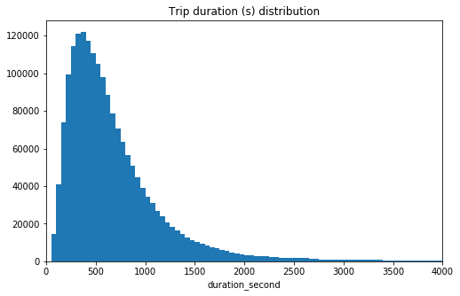

```python
# start with a standard-scaled plot
binsize = 50
bins = np.arange(0, df_bike['duration_sec'].max()+binsize, binsize)

plt.figure(figsize=[8, 5])
plt.hist(data = df_bike, x = 'duration_sec', bins = bins)
plt.xlim(0,4000)
plt.title('Trip duration (s) distribution')
plt.xlabel('duration_second')
plt.show()
```

The distribution is right skewed. There's a long tail in the distribution, so let's put it on a log scale instead.

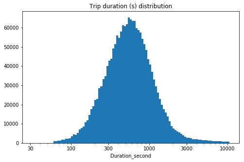

```python
log_binsize = 0.025
bins = 10 ** np.arange(1.5, np.log10(10000)+log_binsize, log_binsize)

plt.figure(figsize=[8, 5])
plt.hist(data = df_bike, x = 'duration_sec', bins = bins)
ticks =  [30, 100, 300, 1000, 3000, 10000]
labels = ['{}'.format(v) for v in ticks]
plt.xscale('log')
plt.xticks(ticks,labels);
plt.xlabel('Duration_second');
plt.title('Trip duration (s) distribution')
plt.show()
```

Next up, the first predictor variable of interest: user_type.

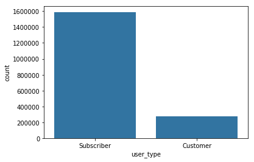

```python
# plotting user_type counts

default_color = sb.color_palette()[0]
sb.countplot(data = df_bike, x = 'user_type', color = default_color)

plt.show()
```

Apparently, in the user_type, the number of 'subscriber' is much larger than 'customer'.

I'll now look at the ’start_time‘ and 'end_time' in the data to see if the season hold interesting properties.

```python
df_bike['month'] = pd.DatetimeIndex(df_bike['start_time']).month
df_bike['month'].value_counts()
```

```
10    201458
7     199222
6     195968
8     192162
9     186217
5     179125
11    134135
12    131363
4     131169
3     111382
2     106718
1      94802
Name: month, dtype: int64
```

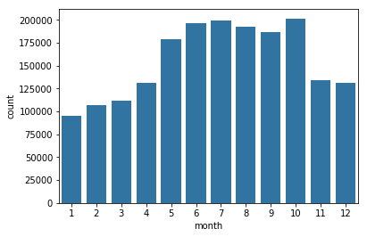

```python
default_color = sb.color_palette()[0]
sb.countplot(data=df_bike, x='month', color=default_color)
```

We can see that more people use bike from June to October. It's worth investigating the relationship between 'month' and 'duration_sec'.

I'll now look at the 'bike_share_for_all_trip' in the data.

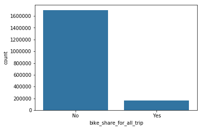

```python
default_color = sb.color_palette()[0]
sb.countplot(data=df_bike, x='bike_share_for_all_trip', color=default_color)
```

We can see that most people didn't choose 'bike_share_for_all_trip'.

### Of the features you investigated, were there any unusual distributions? Did you perform any operations on the data to tidy, adjust, or change the form of the data? If so, why did you do this?

> The 'start_station_latitude','start_station_longitude', 'end_station_latitude', 'end_station_longitude' were firstly dropped because they are insignificant features. There are 11771 null values in 'start_station_id', 'start_station_name', 'end_station_id', 'end_station_name'. Since these four variables are not in the interest of current study, no operation performed.

## Bivariate Exploration

> To start off with, I want to look at the pairwise correlations present between features in the data.

```python
numeric_vars = ['duration_sec', 'month']
categoric_vars = ['user_type', 'bike_share_for_all_trip']
```

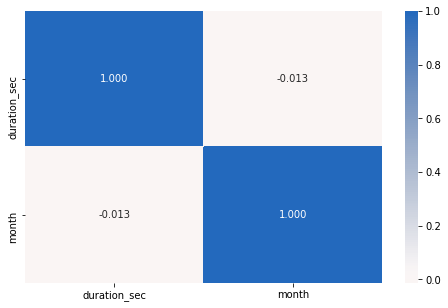

```python
# correlation plot
plt.figure(figsize = [8, 5])
sb.heatmap(df_bike[numeric_vars].corr(), annot = True, fmt = '.3f',
           cmap = 'vlag_r', center = 0)
plt.show()
```

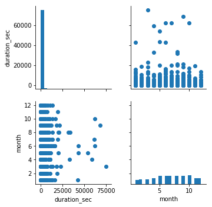

```python
# plot matrix: sample 10000 user information so that plots are clearer and they render faster
samples = np.random.choice(df_bike.shape[0], 10000, replace = False)
bike_samp = df_bike.loc[samples,:]

g = sb.PairGrid(data = bike_samp, vars = numeric_vars)
g = g.map_diag(plt.hist, bins = 20);
g.map_offdiag(plt.scatter)
```

The relationship between 'month' and 'duration_sec' needs to be further investigated.

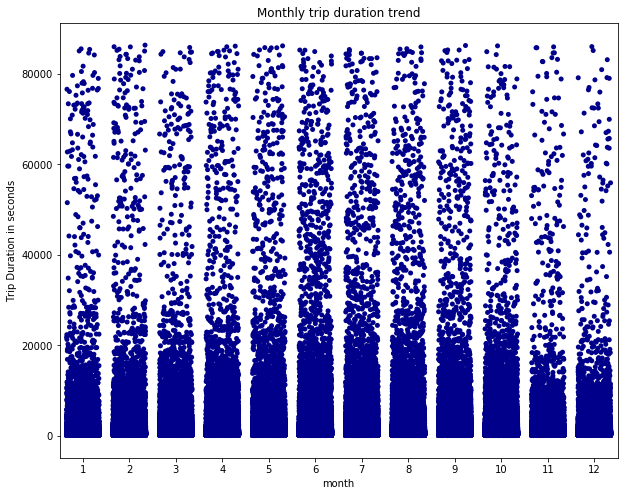

```python
#Let's jitter the data to see more clearly.
plt.figure(figsize=[10,8])
sb.stripplot(data=df_bike, x = 'month', y='duration_sec', jitter=0.35, color="darkblue")
plt.title('Monthly trip duration trend')
plt.xlabel('month')
plt.ylabel('Trip Duration in seconds')
```

It can be seen that the trip duration is longer in June, July and August. Let's see how different season affect the trip duration by transferring 'month' to 'season'.

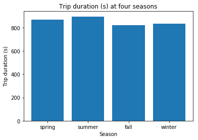

```python
Spring_duration = df_bike.query('month in ["3","4","5"]').duration_sec.mean()
Summer_duration = df_bike.query('month in ["6","7","8"]').duration_sec.mean()
Fall_duration = df_bike.query('month in ["9","10","11"]').duration_sec.mean()
Winter_duration = df_bike.query('month in ["12","1","2"]').duration_sec.mean()

plt.bar(['spring','summer','fall','winter'],[Spring_duration,Summer_duration,Fall_duration,Winter_duration])
plt.title('Trip duration (s) at four seasons')
plt.xlabel('Season')
plt.ylabel('Trip duration (s)')
```

As expected, Spring and Summer have longer trip duration. However, there is no significant difference between each season, possibly because that Bay Area's weather does not change much. I won't be surprised to see a bigger differnece in trip duration in Chicago.

Then, let's look at the relationship between 'user_type' and 'duration_sec'.

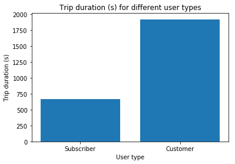

```python
Subscriber_dur = df_bike.query('user_type == "Subscriber"').duration_sec.mean()
Customer_dur = df_bike.query('user_type == "Customer"').duration_sec.mean()

plt.bar(['Subscriber','Customer'], [Subscriber_dur, Customer_dur])
plt.title('Trip duration (s) for different user types')
plt.xlabel('User type')
plt.ylabel('Trip duration (s)')
```

We can see that the 'Customer' have significant longer trip duration than 'Subscriber'.

Then, let's look at the relationship between 'bike_share_for_all_trip' and 'duration_sec'.

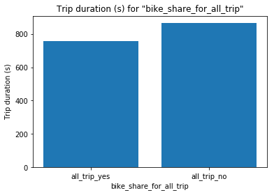

```python
all_trip_yes = df_bike.query('bike_share_for_all_trip == "Yes"').duration_sec.mean()
all_trip_no = df_bike.query('bike_share_for_all_trip == "No"').duration_sec.mean()

plt.bar(['all_trip_yes','all_trip_no'], [all_trip_yes, all_trip_no])
plt.title('Trip duration (s) for "bike_share_for_all_trip"')
plt.xlabel('bike_share_for_all_trip')
plt.ylabel('Trip duration (s)')
```

On average, the trip duration is longer when the 'bike_share_for_all_trip' is not choosed. However, the difference is limited.

### Talk about some of the relationships you observed in this part of the investigation. How did the feature(s) of interest vary with other features in the dataset?

> The trip duration in summer is highest. Different season does have different trip duration, however, the difference is limited. It might becuase that the weather in San Francisco does not change that much.

### Did you observe any interesting relationships between the other features (not the main feature(s) of interest)?

> - the 'Customer' have significant longer trip duration than 'Subscriber'.
> - On average, the trip duration is longer when the 'bike_share_for_all_trip' is not choosed. However, the difference is limited.

## Multivariate Exploration

> The main thing I want to explore in this part of the analysis is how the two categorical variables (user_type and bike_share_for_all_trip) play into the relationship between trip duration and month.

```python
# compute the logarithm of trip duration to make multivariate plotting easier
def log_trans(x, inverse = False):
    """ quick function for computing log and power operations """
    if not inverse:
        return np.log10(x)
    else:
        return np.power(10, x)

df_bike['log_duration_sec'] = df_bike['duration_sec'].apply(log_trans)
```

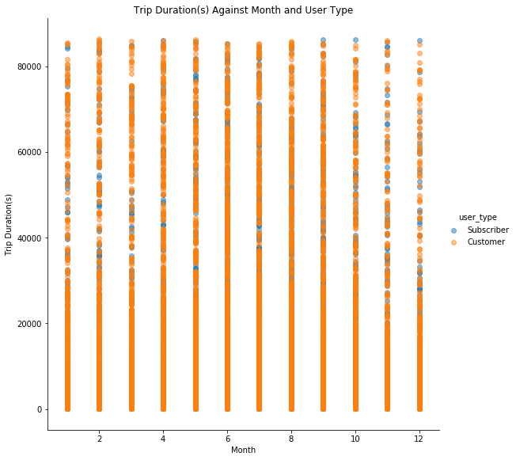

```python
g = sb.FacetGrid(data =  df_bike, hue = 'user_type', size = 8)
g.map(plt.scatter, 'month','duration_sec', alpha = 1/2)
g.add_legend()
plt.title('Trip Duration(s) Against Month and User Type')
plt.xlabel('Month')
plt.ylabel('Trip Duration(s)');
```

It's not clear from the above plot to see how user_type affect the trip duration. The scatter plots is not a good choice for discrete data because of the overplotting issues. Therefore, let's use stripplot to jitter the data.

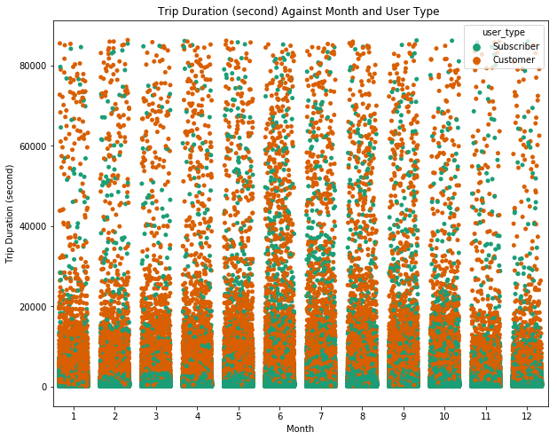

```python
plt.figure(figsize=[10,8])
sb.stripplot(data=df_bike, x='month',y='duration_sec',hue='user_type',jitter=0.35, dodge=False,palette='Dark2')
plt.title('Trip Duration (second) Against Month and User Type ')
plt.xlabel('Month')
plt.ylabel('Trip Duration (second)');
```

```python
bike_flag = (df_bike['month'] >= 6) & (df_bike['month'] <= 8)
bike_1c = df_bike.loc[bike_flag,:]
```

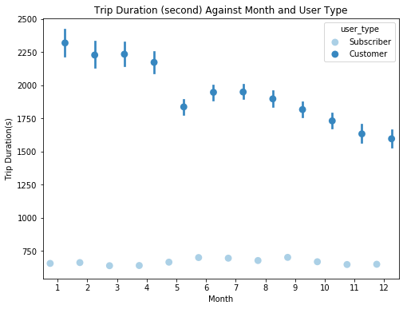

```python
fig = plt.figure(figsize = [8,6])
ax = sb.pointplot(data = df_bike, x = 'month', y = 'duration_sec', hue = 'user_type',
           palette = 'Blues', linestyles = '', dodge = 0.5)
plt.title('Trip Duration (second) Against Month and User Type')
plt.xlabel('Month')
plt.ylabel('Trip Duration(s)');
ax.set_yticklabels([],minor = True)
plt.show();
```

As expected, the above plot further confirms that the customers tend to have a longer trip duration than subscribers.

Let's now see how bike share purpose (bike_share_for_all_trip) affect the trip duration.

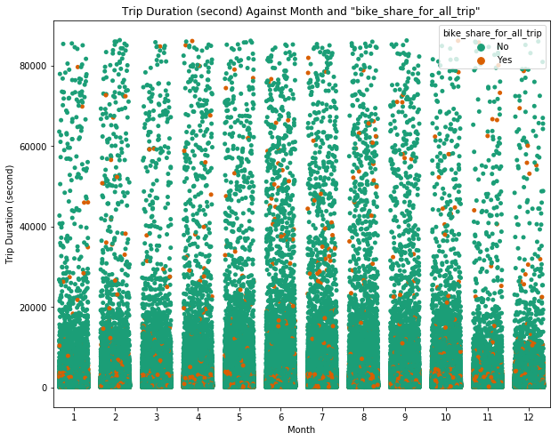

```python
plt.figure(figsize=[10,8])
sb.stripplot(data=df_bike, x='month',y='duration_sec',hue='bike_share_for_all_trip',jitter=0.35, dodge=False,palette='Dark2')
plt.title('Trip Duration (second) Against Month and "bike_share_for_all_trip"')
plt.xlabel('Month')
plt.ylabel('Trip Duration (second)');
```

We can firstly observe that there are more people didn't choose "bike_share_for_all_trip". Also, when the bike_share_for_all_trip is no, the trip duration is longer. Let's further confirm this finding.

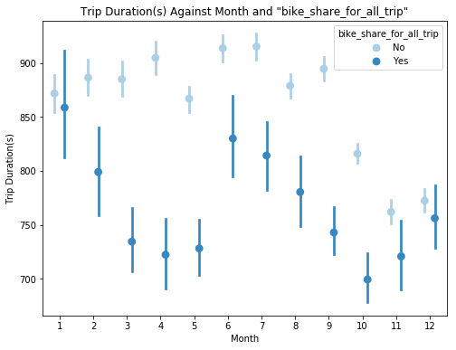

```python
fig = plt.figure(figsize = [8,6])
ax = sb.pointplot(data = df_bike, x = 'month', y = 'duration_sec', hue = 'bike_share_for_all_trip',
           palette = 'Blues', linestyles = '', dodge = 0.3)
plt.title('Trip Duration(s) Against Month and "bike_share_for_all_trip"')
plt.xlabel('Month')
plt.ylabel('Trip Duration(s)');
ax.set_yticklabels([],minor = True)
plt.show();
```

As expected, the above plot further confirms that for the bike_share_for_all_trip, it does make an impact on the trip duration. When the bike_share_for_all_trip is no, the trip duration is longer.

### Were there any interesting or surprising interactions between features?

> An interesting point is that customers tend to rent bikes for longer trips. On average above 30 minutes.